# Rise 2 Flow

B. Penzenstadler & R. Torkar

First version: 2020-12-26. Current version: 2021-02-25 11:23:51.

# 1 Introduction

The Rise 2 Flow study used a number of instruments during the entry, exit, and weekly sessions (additionally personal data was collected during the entry session).

For entry and exit sessions six instruments were used:

- Mindful attention awareness scale (MAAS).[^1]
- Scale of positive and negative experience (SPANE).[^2]
- Personal wellbeing index (PWB).[^3]
- Positive thinking (PST).[^4]
- Self efficacy (SE).[^5]
- Perceived productivity (PP).[^6]

In addition, a seventh instrument, mini-IPIP, was added to the exit session to control for personality type.[^7]

For the weekly sessions the WHO-5 well-being index was used (WHO-5).[^8]

To summarize, the study was executed according to,

1. An entry survey, at time $t_0$
2. A weekly survey, at time $t_{{t_0 + 1}}, \ldots, t_{{t_0+13}}$
3. An exit survey, at time $t_{0+13}$

The main question the study tries to answer is: **Is there a difference in the responses (i.e., higher/lower values on responses), across all or among some instruments, over time?**

In order to answer that question we can first of all compare outcomes of $t_0$ and $t_1$, and contrast with personal data, e.g., age, gender, IPIP. Next, the weekly session can be used to investigate the trend over time, and perhaps see where a noticeable effect, if it exists, shows up.

# 2 Data cleaning

```r
entry <- read.xlsx(here("data/R2F Quant Comp Data Entry.xlsx"))
exit <- read.xlsx(here("data/R2F Quant Comp Data Exit.xlsx"))
weekly <- read.xlsx(here("data/R2F Quant Weekly.xlsx"), detectDates = T)
ipip <- read.xlsx(here("data/R2F IPIP.xlsx"))
pers <- read.xlsx(here("data/R2F Pers Data.xlsx")) # personal data
daily <- read.xlsx(here("data/R2F Daily.xlsx"), detectDates = T) # yes, also daily data
```

## 2.1 `entry` and `exit` datasets

We need to set a number of columns as factors (ordered factors in many cases). Additionally, when we have Yes/No answers, as we do in some questions below, we set them to 0/1 since they will be modeled with a Bernoulli likelihood.

First we clean the `entry` dataset.

```r
for(j in 3:17){
  set(entry, i=NULL, j=j, value=factor(entry[[j]], levels = c("Almost never", "Very infrequently", "Somewhat infrequently", "Somewhat frequently", "Very frequently", "Almost always"), ordered = TRUE))
}

for(j in 18:29){
  set(entry, i=NULL, j=j, value=factor(entry[[j]], levels = c("Very rarely or never", "Rarely", "Sometimes", "Often", "Very often or always"), ordered = TRUE))
}

for(j in 30:37){
  set(entry, i=NULL, j=j, value=factor(entry[[j]], levels = c("Strongly disagree", "Disagree", "Slightly disagree", "Mixed or neither agree nor disagree", "Slightly agree", "Agree", "Strongly agree"), ordered = TRUE))
}

for(i in 38:59)
  entry[,eval(i)] <- ifelse(entry[eval(i)] == 'Yes', 1, 0)

for(j in 60:69){
  set(entry, i=NULL, j=j, value=factor(entry[[j]], levels = c("Hardly true","Rather true","Exactly true"), ordered = TRUE))
}

for(j in 70:76){
  set(entry, i=NULL, j=j, value=factor(entry[[j]], levels = c("None of the time","A little of the time","Some of the time","Most of the time","All of the time"), ordered = TRUE))
}

for(j in 77:79){
  set(entry, i=NULL, j=j, value=factor(entry[[j]], levels = c("1","2","3","4","5","6","7","8","9","10"), ordered = TRUE))
}

for(j in 80:80){
  set(entry, i=NULL, j=j, value=factor(entry[[j]], levels = c("You were a lot worse than other workers","You were a little worse than other workers","You were somewhat worse than other workers","You were about average","You were somewhat better than other workers","You were a little better than other workers","You were a lot better than other workers"), ordered = TRUE))
}
```

Next, we clean the `exit` dataset, which consists of the same variables as above.

```r
for(j in 3:17){
  set(exit, i=NULL, j=j, value=factor(exit[[j]], levels = c("Almost never", "Very infrequently", "Somewhat infrequently", "Somewhat frequently", "Very frequently", "Almost always"), ordered = TRUE))
}

for(j in 18:29){
  set(exit, i=NULL, j=j, value=factor(exit[[j]], levels = c("Very rarely or never", "Rarely", "Sometimes", "Often", "Very often or always"), ordered = TRUE))
}

for(j in 30:37){
  set(exit, i=NULL, j=j, value=factor(exit[[j]], levels = c("Strongly disagree", "Disagree", "Slightly disagree", "Mixed or neither agree nor disagree", "Slightly agree", "Agree", "Strongly agree"), ordered = TRUE))
}

for(i in 38:59)
  exit[,eval(i)] <- ifelse(exit[eval(i)] == 'Yes', 1, 0)


for(j in 60:69){
  set(exit, i=NULL, j=j, value=factor(exit[[j]], levels = c("Hardly true","Rather true","Exactly true"), ordered = TRUE))
}

for(j in 70:76){
  set(exit, i=NULL, j=j, value=factor(exit[[j]], levels = c("None of the time","A little of the time","Some of the time","Most of the time","All of the time"), ordered = TRUE))
}

for(j in 77:79){
  set(exit, i=NULL, j=j, value=factor(exit[[j]], levels = c("1","2","3","4","5","6","7","8","9","10"), ordered = TRUE))
}

for(j in 80:80){
  set(exit, i=NULL, j=j, value=factor(exit[[j]], levels = c("You were a lot worse than other workers","You were a little worse than other workers","You were somewhat worse than other workers","You were about average","You were somewhat better than other workers","You were a little better than other workers","You were a lot better than other workers"), ordered = TRUE))
}
```

## 2.2 `weekly` dataset

The `weekly` dataset contains five columns of the same type, which we set as ordered categorical.

```r
for(j in 4:8){
  set(weekly, i=NULL, j=j, value=factor(weekly[[j]], levels = c("At no time", "Less than half of the time", "Some of the time", "More than half of the time",  "Most of the time", "All of the time"), ordered = TRUE))
}
```

## 2.3 `ipip` dataset

The mini-IPIP instrument uses only five levels for all 20 questions (ordered categorical).

```r
for(j in 3:22){
  set(ipip, i=NULL, j=j, value=factor(ipip[[j]], levels = c("Disagree", "Somewhat disagree", "Neither agree nor disagree", "Somewhat agree", "Agree"), ordered = TRUE))
}
```

## 2.4 `pers` dataset

In the `pers` dataset we have a mix of variable types we need to deal with. `Age` should be scaled, `Gender` and `Occupation` set to 1/2, and `Living conditions` set to factors (unordered).

```r
# convert Age to numeric and standardize (note we have two NAs, so we suppress the warning we get)
suppressWarnings(pers$Age <- scale(as.numeric(pers$Age)))

# set 1/2 as indicators for gender
pers$Gender_0_1 <- ifelse(pers$Gender_0_1 == "Man/Transman", 1, 2)

# many categories exist for occupation, but let's simplify this so we can
# use this variable for something. Indicate if they are students or not.
pers$Occupation <- ifelse(pers$Occupation == "Student", 1, 2)

# make living condition a categorical factor (unordered)
pers$Living_1_4 <- factor(pers$Living_1_4, levels = c("I live by myself", "I live in shared housing", "I live with a partner", "I live with my family"))

# remove the last three columns since we have >64% NAs
pers[,7:9] <- NULL
```

## 2.5 Missingness analysis

Check how many cells are NA.

```r
table(is.na(entry))
```

```
##
## FALSE  TRUE
##  6862    98
```

```r
table(is.na(exit))
```

```
##
## FALSE  TRUE
##  2684    36
```

```r
table(is.na(weekly))
```

```
##
## FALSE  TRUE
##  2390     2
```

```r
table(is.na(pers))
```

```
##
## FALSE  TRUE
##   519     3
```

```r
entry <- entry[complete.cases(entry), ]
exit <- exit[complete.cases(exit), ]
weekly <- weekly[complete.cases(weekly), ]
pers <- pers[complete.cases(pers), ]
```

Remember, the main question the study tries to answer is: **Is there a difference in the responses (i.e., higher/lower values on responses), across all or among some instruments, over time?** This means that for now we can discard of the weekly data and instead focus on the entry and exit instruments, together with personal data (i.e., age, gender, occupation, and living conditions).

In order for us to conduct inferences along this line of thinking, we will make use of dummy variable regression estimators (DVRE), which is numerically identical to deviation score estimators. The DVRE approach dummy encodes our time variable $t$ and sets an index $0/1$, where $t_0 = 0$ and $t_1 = 1$. In short, each subject (`ID`) will have two rows where one row is the entry instrument $t = 0$, and one row has the exit instrument $t = 1$. We’ll create six datasets which are divided according to each instrument we use as outcome (MAAS, SPANE, PWB, PST, SE, and PP), and then see if our predictors are useful for predicting the outcome (i.e., is there a significant difference in the $\beta$ estimators) and then also investigate if the outcome at $t_0$ equals $t_1$ (and if they aren’t the same, how much do they differ?)

```r
# create new column t, and set to 0 or 1
entry$t <- 0
exit$t <- 1

# Remove all suffixes in both files so we have the same column names
colnames(entry) <- gsub('_en', '', colnames(entry))
colnames(exit) <- gsub('_ex', '', colnames(exit))

# also remove all dashes and underscores in column names
colnames(entry) <- gsub('_', '', colnames(entry))
colnames(exit) <- gsub('_', '', colnames(exit))
colnames(entry) <- gsub('-', '', colnames(entry))
colnames(exit) <- gsub('-', '', colnames(exit))
colnames(ipip) <- gsub('_', '', colnames(ipip))
colnames(pers) <- gsub('_', '', colnames(pers))
colnames(ipip) <- gsub('-', '', colnames(ipip))
colnames(pers) <- gsub('-', '', colnames(pers))

# add rows of entry and exit
d <- rbind(entry, exit)

# keep only rows if they show up twice, so we have a within-measurement of each # individual at time t_0 and t_1
d <- ddply(d, .(ID), function(x){
    if(nrow(x)==1){
        return(NULL)
    }
    else{
        return(x)
    }
})

table(d$t)
```

```
##
##  0  1
## 13 13
```

We have $13$ individuals with entry and exit surveys completely filled out. Let’s also add the `ipip` and `pers` datasets, and then use only individuals with complete data.

```r
d <- inner_join(d, pers, by = "ID")
d <- inner_join(d, ipip, by = "ID")
```

After joining these two datasets we have 12 subjects in the dataset.

# 3 Model designs

## 3.1 Data-generative distribution

```r
bf1 <- bf(mvbind(MAASQ116,
                 MAASQ216,
                 MAASQ316,
                 MAASQ416,
                 MAASQ516,
                 MAASQ616,
                 MAASQ716,
                 MAASQ816,
                 MAASQ916,
                 MAASQ1016,
                 MAASQ1116,
                 MAASQ1216,
                 MAASQ1316,
                 MAASQ1416,
                 MAASQ1516) ~
            1 )

m0 <- brm(bf1,
    family = cumulative,
    data = d,
    silent = TRUE,
    refresh = 0
    )
```

```
## Running MCMC with 4 parallel chains...
##
## Chain 2 finished in 17.5 seconds.
## Chain 3 finished in 17.5 seconds.
## Chain 1 finished in 17.8 seconds.
## Chain 4 finished in 18.0 seconds.
##
## All 4 chains finished successfully.
## Mean chain execution time: 17.7 seconds.
## Total execution time: 18.5 seconds.
```

```r
mcr <- brm(bf1,
    family = cratio,
    data = d,
    silent = TRUE,
    refresh = 0
    )
```

```
## Running MCMC with 4 parallel chains...
##
## Chain 2 finished in 4.1 seconds.
## Chain 1 finished in 4.1 seconds.
## Chain 3 finished in 5.3 seconds.
## Chain 4 finished in 5.3 seconds.
##
## All 4 chains finished successfully.
## Mean chain execution time: 4.7 seconds.
## Total execution time: 5.6 seconds.
```

```r
msr <- brm(bf1,
    family = sratio,
    data = d,
    silent = TRUE,
    refresh = 0
    )
```

```
## Running MCMC with 4 parallel chains...
##
## Chain 2 finished in 5.2 seconds.
## Chain 4 finished in 6.2 seconds.
## Chain 1 finished in 6.3 seconds.
## Chain 3 finished in 6.5 seconds.
##
## All 4 chains finished successfully.
## Mean chain execution time: 6.1 seconds.
## Total execution time: 6.8 seconds.
```

```r
mac <- brm(bf1,
    family = acat,
    data = d,
    silent = TRUE,
    refresh = 0
    )
```

```
## Running MCMC with 4 parallel chains...
##
## Chain 1 finished in 8.5 seconds.
## Chain 2 finished in 8.5 seconds.
## Chain 4 finished in 8.6 seconds.
## Chain 3 finished in 9.0 seconds.
##
## All 4 chains finished successfully.
## Mean chain execution time: 8.6 seconds.
## Total execution time: 9.3 seconds.
```

```r
m0 <- add_criterion(m0, criterion = "loo")
msr <- add_criterion(msr, criterion = "loo")
mcr <- add_criterion(mcr, criterion = "loo")
mac <- add_criterion(mac, criterion = "loo")

loo_compare(m0, mcr, msr, mac)
```

```
##     elpd_diff se_diff
## m0   0.0       0.0
## mcr -2.7       3.1
## msr -2.8       3.1
## mac -3.1       1.6
```

## 3.2 Prior and posterior predictive checks

## 3.3 `weekly` data

We want to model the weekly instrument and how it varies over time $t$. In this case, $t$ will be modeled using a Gaussian Process and then each individual in the dataset will be modeled using a varying intercept.

```r
# Make sure ID is a factor
weekly$ID <- as.factor(weekly$ID)

# Also keep ordered categorical as integer Q1,..,Q5
weekly$Q1 <- as.integer(weekly$WQ1_1_6)
weekly$Q2 <- as.integer(weekly$WQ2_1_6)
weekly$Q3 <- as.integer(weekly$WQ3_1_6)
weekly$Q4 <- as.integer(weekly$WQ4_1_6)
weekly$Q5 <- as.integer(weekly$WQ5_1_6)
```

```r
# Let's use GP to model over time, it'll be the same priors for all
weekly$Date_i <- as.numeric(weekly$Date)
weekly <- weekly[complete.cases(weekly), ]

p <- get_prior(WQ1_1_6 ~ gp(Date_i) + (1 | ID), data = weekly,
               family = cumulative())
p$prior[1] <- "normal(0,5)"
p$prior[c(8,11)] <- "weibull(2,1)"

WQ1gp <- brm(WQ1_1_6 ~ gp(Date_i) + (1 | ID), data = weekly,
             family = cumulative(), prior = p, control = list(adapt_delta=0.95),
             silent = TRUE, refresh = 0)
```

```
## Running MCMC with 4 parallel chains...
##
## Chain 4 finished in 35.2 seconds.
## Chain 2 finished in 38.6 seconds.
## Chain 1 finished in 40.1 seconds.
## Chain 3 finished in 40.3 seconds.
##
## All 4 chains finished successfully.
## Mean chain execution time: 38.6 seconds.
## Total execution time: 40.7 seconds.
```

```r
WQ2gp <- brm(WQ2_1_6 ~ gp(Date_i) + (1 | ID), data = weekly,
             family = cumulative(), prior = p, control = list(adapt_delta=0.95),
             silent = TRUE, refresh = 0)
```

```
## Running MCMC with 4 parallel chains...
##
## Chain 1 finished in 47.7 seconds.
## Chain 4 finished in 48.5 seconds.
## Chain 3 finished in 49.6 seconds.
## Chain 2 finished in 51.1 seconds.
##
## All 4 chains finished successfully.
## Mean chain execution time: 49.2 seconds.
## Total execution time: 51.4 seconds.
```

```r
WQ3gp <- brm(WQ3_1_6 ~ gp(Date_i) + (1 | ID), data = weekly,
             family = cumulative(), prior = p, control = list(adapt_delta=0.95),
             silent = TRUE, refresh = 0)
```

```
## Running MCMC with 4 parallel chains...
##
## Chain 2 finished in 40.8 seconds.
## Chain 3 finished in 44.2 seconds.
## Chain 1 finished in 45.2 seconds.
## Chain 4 finished in 45.3 seconds.
##
## All 4 chains finished successfully.
## Mean chain execution time: 43.8 seconds.
## Total execution time: 45.6 seconds.
```

```r
WQ4gp <- brm(WQ4_1_6 ~ gp(Date_i) + (1 | ID), data = weekly,
             family = cumulative(), prior = p, control = list(adapt_delta=0.96),
             silent = TRUE, refresh = 0)
```

```
## Running MCMC with 4 parallel chains...
##
## Chain 3 finished in 36.7 seconds.
## Chain 2 finished in 43.5 seconds.
## Chain 4 finished in 43.6 seconds.
## Chain 1 finished in 46.5 seconds.
##
## All 4 chains finished successfully.
## Mean chain execution time: 42.6 seconds.
## Total execution time: 46.8 seconds.
```

```r
WQ5gp <- brm(WQ5_1_6 ~ gp(Date_i) + (1 | ID), data = weekly,
             family = cumulative(), prior = p, control = list(adapt_delta=0.95),
             silent = TRUE, refresh = 0)
```

```
## Running MCMC with 4 parallel chains...
##
## Chain 1 finished in 53.0 seconds.
## Chain 3 finished in 55.6 seconds.
## Chain 2 finished in 57.7 seconds.
## Chain 4 finished in 58.0 seconds.
##
## All 4 chains finished successfully.
## Mean chain execution time: 56.1 seconds.
## Total execution time: 58.3 seconds.
```

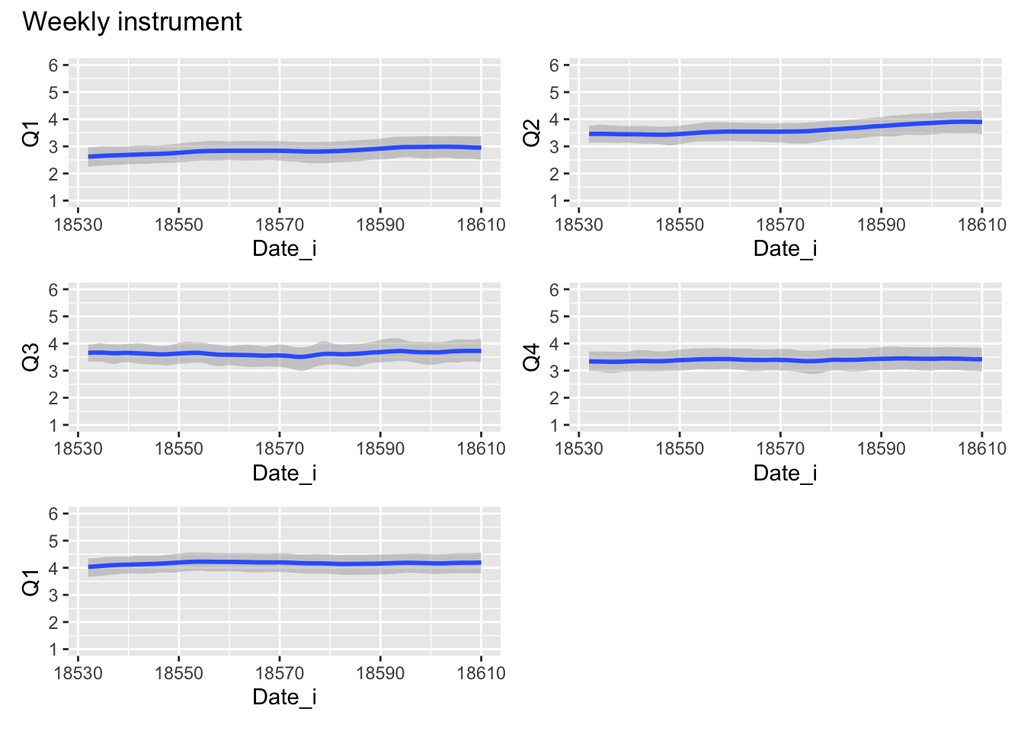

```r
# Set the same y axis on all plots
p1 <- plot(conditional_effects(WQ1gp), plot = FALSE)[[1]] +
  scale_y_continuous(name = "Q1",
                     limits = c(1, 6),
                     breaks = seq(1:6))
p2 <- plot(conditional_effects(WQ2gp), plot = FALSE)[[1]] +
  scale_y_continuous(name = "Q2",
                     limits = c(1, 6),
                     breaks = seq(1:6))
p3 <- plot(conditional_effects(WQ3gp), plot = FALSE)[[1]] +
  scale_y_continuous(name = "Q3",
                     limits = c(1, 6),
                     breaks = seq(1:6))
p4 <- plot(conditional_effects(WQ4gp), plot = FALSE)[[1]] +
  scale_y_continuous(name = "Q4",
                     limits = c(1, 6),
                     breaks = seq(1:6))
p5 <- plot(conditional_effects(WQ5gp), plot = FALSE)[[1]] +
  scale_y_continuous(name = "Q1",
                     limits = c(1, 6),
                     breaks = seq(1:6))
p1 + p2 + p3 + p4 + p5 +
  plot_layout(ncol=2) +
  plot_annotation(title = 'Weekly instrument')
```

In short, very little happening over time according to the weekly instrument.

## 3.4 `daily` data

Let’s redo this but for the `daily` dataset.

```r
daily$ID <- as.factor(daily$ID)
daily$date_s <- as.numeric(daily$date)

p <- get_prior(resp ~ 1 + gp(date_s) + (1| ID), data = daily, family = cumulative)
p$prior[1] <- "normal(0,5)"
p$prior[c(13,16)] <- "weibull(2,1)"

m_daily <- brm(resp ~ 1 + gp(date_s) + (1| ID),
               data = daily,
               family = cumulative,
               prior = p,
               control = list(adapt_delta=0.95),
               iter = 8e3,
               silent = TRUE,
               refresh = 0)#, threads = threading(2))
```

```
## Running MCMC with 4 parallel chains...
##
## Chain 1 finished in 897.3 seconds.
## Chain 3 finished in 1032.5 seconds.
## Chain 2 finished in 1249.5 seconds.
## Chain 4 finished in 1250.8 seconds.
##
## All 4 chains finished successfully.
## Mean chain execution time: 1107.5 seconds.
## Total execution time: 1251.3 seconds.
```

Sampled good but we needed to run the chains longer to find the typical set.

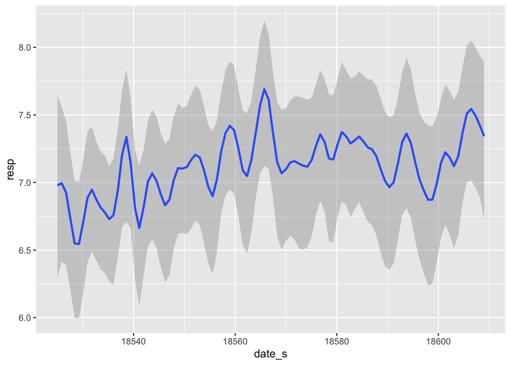

```r
conditional_effects(m_daily)
```

Weak positive trend, but nothing significant really.

## 3.5 Multivariate models with temporal variable

We want a model that uses personal data (e.g., age) as predictors. The idea is to later see if any of the predictors have predictive capacity for our six different survey instruments.

First, design a model with predictors from `personal` data and compare with our null model ($\mathcal{M}_0$), together with our indicator $t$ for time, and a varying intercept `ID` that varies depending on subject.

```r
bf1 <- bf(mvbind(MAASQ116,
                 MAASQ216,
                 MAASQ316,
                 MAASQ416,
                 MAASQ516,
                 MAASQ616,
                 MAASQ716,
                 MAASQ816,
                 MAASQ916,
                 MAASQ1016,
                 MAASQ1116,
                 MAASQ1216,
                 MAASQ1316,
                 MAASQ1416,
                 MAASQ1516) ~
            1 + Age + Gender01 + Occupation + Living14 + t + (1|ID))

m_pers <- brm(bf1,
    family = cumulative,
    data = d,
    silent = TRUE,
    refresh = 0)#,
```

```
## Running MCMC with 4 parallel chains...
##
## Chain 4 finished in 164.1 seconds.
## Chain 1 finished in 187.1 seconds.
## Chain 2 finished in 193.2 seconds.
## Chain 3 finished in 327.5 seconds.
##
## All 4 chains finished successfully.
## Mean chain execution time: 218.0 seconds.
## Total execution time: 328.0 seconds.
```

```r
    #threads = threading(2))

m_pers <- add_criterion(m_pers, criterion = "loo")

# compare the new model with our null model, it should hopefully be better...
(l <- loo_compare(m0, m_pers))
```

[output not shown]

```r
l[2,1] + c(-1,1) * 1.96 * l[2,2]
```

```
## [1] -87.327351   2.811668
```

Let’s now sample all models with the same predictors we used above (visual prior and posterior predictive checks were done for each model).

```r
################################################################################
#
# MAAS
#
################################################################################
bf1 <- bf(mvbind(MAASQ116,
                 MAASQ216,
                 MAASQ316,
                 MAASQ416,
                 MAASQ516,
                 MAASQ616,
                 MAASQ716,
                 MAASQ816,
                 MAASQ916,
                 MAASQ1016,
                 MAASQ1116,
                 MAASQ1216,
                 MAASQ1316,
                 MAASQ1416,
                 MAASQ1516) ~
            1 + Age + Gender01 + Occupation + Living14 + t + (1 |c| ID))

# Prior predictive checks have been conducted and the probability mass
# is distributed evenly on the outcome space
p <- get_prior(bf1, data=d, family=cumulative) %>%
  mutate(prior = ifelse(class == "b", "normal(0,3)", prior)) %>%
  mutate(prior = ifelse(class == "cor", "lkj(2)", prior)) %>%
  mutate(prior = ifelse(class == "Intercept", "normal(0,5)", prior)) %>%
  mutate(prior = ifelse(class == "sd", "weibull(2,1)", prior))


m_maas <- brm(bf1,
    family = cumulative,
    data = d,
    prior = p,
    #sample_prior = "only", # use if you only want to sample from prior
    silent = TRUE,
    refresh = 0)#,
```

```
## Running MCMC with 4 parallel chains...
##
## Chain 1 finished in 31.0 seconds.
## Chain 4 finished in 31.0 seconds.
## Chain 2 finished in 31.3 seconds.
## Chain 3 finished in 32.1 seconds.
##
## All 4 chains finished successfully.
## Mean chain execution time: 31.4 seconds.
## Total execution time: 32.5 seconds.
```

```r
    #threads = threading(2))

# use the below to do prior and posterior predictive checks
# change resp to the response variable you want to check
# pp_check(m_maas, resp = "MAASQ116", type = "bars, nsamples = 250)
```

```r
################################################################################
#
# SPANE
#
################################################################################

bf1 <- bf(mvbind(SPANEQ115,
                 SPANEQ215,
                 SPANEQ315,
                 SPANEQ415,
                 SPANEQ515,
                 SPANEQ615,
                 SPANEQ715,
                 SPANEQ815,
                 SPANEQ915,
                 SPANEQ1015,
                 SPANEQ1115,
                 SPANEQ1215) ~
            1 + Age + Gender01 + Occupation + Living14 + t + (1 |c| ID))

p <- get_prior(bf1, data=d, family=cumulative) %>%
  mutate(prior = ifelse(class == "b", "normal(0,3)", prior)) %>%
  mutate(prior = ifelse(class == "cor", "lkj(2)", prior)) %>%
  mutate(prior = ifelse(class == "Intercept", "normal(0,5)", prior)) %>%
  mutate(prior = ifelse(class == "sd", "weibull(2,1)", prior))

m_spane <- brm(bf1,
    family = cumulative,
    data = d,
    prior = p,
    # sample_prior = "only", # use if you only want to sample from prior
    silent = TRUE,
    refresh = 0)#,
```

```
## Running MCMC with 4 parallel chains...
##
## Chain 3 finished in 18.7 seconds.
## Chain 4 finished in 19.0 seconds.
## Chain 1 finished in 19.1 seconds.
## Chain 2 finished in 19.1 seconds.
##
## All 4 chains finished successfully.
## Mean chain execution time: 19.0 seconds.
## Total execution time: 19.5 seconds.
```

```r
    #threads = threading(2))

# use the below to do prior and posterior predictive checks
# change resp to the response variable you want to check
# pp_check(m_spane, resp = "SPANEQ115", type = "bars", nsamples = 250)
```

```r
################################################################################
#
# PWB
#
################################################################################

bf1 <- bf(mvbind(PWBQ117,
                 PWBQ217,
                 PWBQ317,
                 PWBQ417,
                 PWBQ517,
                 PWBQ617,
                 PWBQ717,
                 PWBQ817) ~
            1 + Age + Gender01 + Occupation + Living14 + t + (1 |c| ID))

p <- get_prior(bf1, data=d, family=cumulative) %>%
  mutate(prior = ifelse(class == "b", "normal(0,3)", prior)) %>%
  mutate(prior = ifelse(class == "cor", "lkj(2)", prior)) %>%
  mutate(prior = ifelse(class == "Intercept", "normal(0,5)", prior)) %>%
  mutate(prior = ifelse(class == "sd", "weibull(2,1)", prior))

m_pwb <- brm(bf1,
    family = cumulative,
    data = d,
    prior = p,
    # sample_prior = "only", # use if you only want to sample from prior
    silent = TRUE,
    refresh = 0)#,
```

```
## Running MCMC with 4 parallel chains...
##
## Chain 4 finished in 14.0 seconds.
## Chain 1 finished in 14.2 seconds.
## Chain 2 finished in 14.2 seconds.
## Chain 3 finished in 14.8 seconds.
##
## All 4 chains finished successfully.
## Mean chain execution time: 14.3 seconds.
## Total execution time: 15.2 seconds.
```

```r
    #threads = threading(2))

# pp_check(m_pwb, resp = "PWBQ117", type = "bars", nsamples = 250)
```

```r
################################################################################
#
# PST
#
################################################################################
# Here we move to a bernoulli since we have 0/1 outcome
bf1 <- bf(mvbind(PSTQ101,
                 PSTQ201,
                 PSTQ301,
                 PSTQ401,
                 PSTQ501,
                 PSTQ601,
                 PSTQ701,
                 PSTQ801,
                 PSTQ901,
                 PSTQ1001,
                 PSTQ1101,
                 PSTQ1201,
                 PSTQ1301,
                 PSTQ1401,
                 PSTQ1501,
                 PSTQ1601,
                 PSTQ1701,
                 PSTQ1801,
                 PSTQ1901,
                 PSTQ2001,
                 PSTQ2101,
                 PSTQ2201) ~
            1 + Age + Gender01 + Occupation + Living14 + t + (1 |c| ID))

p <- get_prior(bf1, data=d, family=bernoulli) %>%
  mutate(prior = ifelse(class == "b", "normal(0,3)", prior)) %>%
  mutate(prior = ifelse(class == "cor", "lkj(2)", prior)) %>%
  mutate(prior = ifelse(class == "Intercept", "normal(0,5)", prior)) %>%
  mutate(prior = ifelse(class == "sd", "weibull(2,1)", prior))

m_pst <- brm(bf1,
    family = bernoulli,
    data = d,
    prior = p,
    # sample_prior = "only",
    silent = TRUE,
    refresh = 0
    )
```

```
## Running MCMC with 4 parallel chains...
##
## Chain 1 finished in 11.0 seconds.
## Chain 3 finished in 11.1 seconds.
## Chain 2 finished in 11.2 seconds.
## Chain 4 finished in 11.3 seconds.
##
## All 4 chains finished successfully.
## Mean chain execution time: 11.2 seconds.
## Total execution time: 11.7 seconds.
```

```r
# pp_check(m_pst, resp = "PSTQ101", type = "bars", nsamples = 250)
```

```r
################################################################################
#
# SE - two models (Cumulative and Bernoulli), both multivariate
#
################################################################################
# NOTE: the first two questions can be analyzed as Bernoulli
bf1 <- bf(mvbind(#SEQ114, # this and the next outcome only has two categories
                 #SEQ214,
                 SEQ314,
                 SEQ414,
                 SEQ514,
                 SEQ614,
                 SEQ714,
                 SEQ814,
                 SEQ914,
                 SEQ1014) ~
            1 + Age + Gender01 + Occupation + Living14 + t + (1 |c| ID))

p <- get_prior(bf1, data=d, family=cumulative) %>%
  mutate(prior = ifelse(class == "b", "normal(0,3)", prior)) %>%
  mutate(prior = ifelse(class == "cor", "lkj(2)", prior)) %>%
  mutate(prior = ifelse(class == "Intercept", "normal(0,5)", prior)) %>%
  mutate(prior = ifelse(class == "sd", "weibull(2,1)", prior))

m_se <- brm(bf1,
    family = cumulative,
    data = d,
    prior = p,
    # sample_prior = "only",
    silent = TRUE,
    refresh = 0)#,
```

```
## Running MCMC with 4 parallel chains...
##
## Chain 4 finished in 8.5 seconds.
## Chain 1 finished in 8.9 seconds.
## Chain 3 finished in 9.7 seconds.
## Chain 2 finished in 10.0 seconds.
##
## All 4 chains finished successfully.
## Mean chain execution time: 9.3 seconds.
## Total execution time: 10.3 seconds.
```

```r
    #threads = threading(2))

# pp_check(m_seq, resp = "SEQ314", type = "bars", nsamples = 250)

# next take the two questions that only had answers on two levels
bf1 <- bf(mvbind(SEQ114,
                 SEQ214) ~
            1 + Age + Gender01 + Occupation + Living14 + t + (1 |c| ID))

p <- get_prior(bf1, data=d, family=bernoulli) %>%
  mutate(prior = ifelse(class == "b", "normal(0,3)", prior)) %>%
  mutate(prior = ifelse(class == "cor", "lkj(2)", prior)) %>%
  mutate(prior = ifelse(class == "Intercept", "normal(0,5)", prior)) %>%
  mutate(prior = ifelse(class == "sd", "weibull(2,1)", prior))

m_se2 <- brm(bf1,
    family = bernoulli,
    data = d,
    prior = p,
    # sample_prior = "only",
    silent = TRUE,
    refresh = 0
    )
```

```
## Running MCMC with 4 parallel chains...
##
## Chain 1 finished in 0.3 seconds.
## Chain 2 finished in 0.3 seconds.
## Chain 3 finished in 0.3 seconds.
## Chain 4 finished in 0.3 seconds.
##
## All 4 chains finished successfully.
## Mean chain execution time: 0.3 seconds.
## Total execution time: 0.6 seconds.
```

```r
# pp_check(m_seq2, resp = "SEQ114", type = "bars", nsamples = 250)
```

```r
################################################################################
#
# PPHQ
#
################################################################################


bf1 <- bf(mvbind(PPHQ115,
                 PPHQ215,
                 PPHQ315,
                 PPHQ415,
                 PPHQ515,
                 PPHQ615,
                 PPHQ715,
                 PPRQ1110,
                 PPRQ2110,
                 PPRQ3110,
                 PPOQ117
                 ) ~
            1 + Age + Gender01 + Occupation + Living14 + t + (1 |c| ID))

p <- get_prior(bf1, data=d, family=cumulative) %>%
  mutate(prior = ifelse(class == "b", "normal(0,3)", prior)) %>%
  mutate(prior = ifelse(class == "cor", "lkj(2)", prior)) %>%
  mutate(prior = ifelse(class == "Intercept", "normal(0,5)", prior)) %>%
  mutate(prior = ifelse(class == "sd", "weibull(2,1)", prior))

m_pph <- brm(bf1,
    family = cumulative,
    data = d,
    prior = p,
    # sample_prior = "only",
    silent = TRUE,
    refresh = 0,
    # threads = threading(2)
    )
```

```
## Running MCMC with 4 parallel chains...
##
## Chain 3 finished in 18.4 seconds.
## Chain 2 finished in 18.6 seconds.
## Chain 4 finished in 19.1 seconds.
## Chain 1 finished in 19.5 seconds.
##
## All 4 chains finished successfully.
## Mean chain execution time: 18.9 seconds.
## Total execution time: 19.9 seconds.
```

```r
# pp_check(m_pphq, resp = "PPHQ115", type = "bars", nsamples = 250)
```

So we have now sampled seven models. For each instrument we have one multivariate model ($>1$ outcome), where we also estimate the correlation between the outcome given the subject’s ID.

Most of the models are using, as we’ve already discussed, the Cumulative family. However, in a few cases we use the Bernoulli family. First, we use it for outcomes that were binary (i.e., Yes/No outcomes). Second, we use it for two questions in the SE instrument ($\mathcal{M}_{\text{SE}2}$), which only had empirical outcomes on two levels.

Before we put any trust in these models we need to check a number of diagnostics.

## 3.6 Diagnostics

First, we check general HMC diagnostics. Second, we check that $\widehat{R} \leq 1.01$ and that the effective sample size (ESS) is $\geq 0.2$.

```r
models <- list(m_maas, m_spane, m_pwb, m_pst, m_se, m_se2, m_pph)

# Check divergences, tree depth, energy for each model
for(m in models) {
  rstan::check_hmc_diagnostics(eval(m)$fit)
}
```

```
##
## Divergences:
```

```
## 0 of 4000 iterations ended with a divergence.
```

```
##
## Tree depth:
```

```
## 0 of 4000 iterations saturated the maximum tree depth of 10.
```

```
##
## Energy:
```

```
## E-BFMI indicated no pathological behavior.
```

```
##
## Divergences:
```

```
## 0 of 4000 iterations ended with a divergence.
```

```
##
## Tree depth:
```

```
## 0 of 4000 iterations saturated the maximum tree depth of 10.
```

```
##
## Energy:
```

```
## E-BFMI indicated no pathological behavior.
```

```
##
## Divergences:
```

```
## 0 of 4000 iterations ended with a divergence.
```

```
##
## Tree depth:
```

```
## 0 of 4000 iterations saturated the maximum tree depth of 10.
```

```
##
## Energy:
```

```
## E-BFMI indicated no pathological behavior.
```

```
##
## Divergences:
```

```
## 0 of 4000 iterations ended with a divergence.
```

```
##
## Tree depth:
```

```
## 0 of 4000 iterations saturated the maximum tree depth of 10.
```

```
##
## Energy:
```

```
## E-BFMI indicated no pathological behavior.
```

```
##
## Divergences:
```

```
## 0 of 4000 iterations ended with a divergence.
```

```
##
## Tree depth:
```

```
## 0 of 4000 iterations saturated the maximum tree depth of 10.
```

```
##
## Energy:
```

```
## E-BFMI indicated no pathological behavior.
```

```
##
## Divergences:
```

```
## 0 of 4000 iterations ended with a divergence.
```

```
##
## Tree depth:
```

```
## 0 of 4000 iterations saturated the maximum tree depth of 10.
```

```
##
## Energy:
```

```
## E-BFMI indicated no pathological behavior.
```

```
##
## Divergences:
```

```
## 0 of 4000 iterations ended with a divergence.
```

```
##
## Tree depth:
```

```
## 0 of 4000 iterations saturated the maximum tree depth of 10.
```

```
##
## Energy:
```

```
## E-BFMI indicated no pathological behavior.
```

```r
# Check rhat and neff
for(m in models) {
  if(max(rhat(eval(m)), na.rm=T) >= 1.01) # diag in corr matrix always NA
    print("Warning: Rhat >= 1.01")
  if(min(neff_ratio(eval(m)), na.rm=T) <= 0.2) # diag in corr matrix always NA
    print("Warning: ESS <= 0.2")
}
```

Hamiltonian Monte Carlo diagnostics indicate all is well, $\widehat{R} \leq 1.01$, and $\text{ESS} \geq 0.2$. One can also check traceplots for all models (i.e., using `plot(model)`).

Check how much time it takes to compile this document.

```r
end.time <- Sys.time()
round((end.time - start.time), 1)
```

```
## Time difference of 2.2 mins
```

# 5 References

[^1]: https://ppc.sas.upenn.edu/resources/questionnaires-researchers/mindful-attention-awareness-scale
[^2]: https://www.midss.org/content/scale-positive-and-negative-experience-spane-0
[^3]: http://www.acqol.com.au/instruments
[^4]: https://www.psytoolkit.org/survey-library/pts.html
[^5]: https://sparqtools.org/mobility-measure/new-general-self-efficacy-scale/
[^6]: https://www.hcp.med.harvard.edu/hpq/info.php
[^7]: https://ipip.ori.org/MiniIPIPKey.htm
[^8]: https://www.psykiatri-regionh.dk/who-5/who-5-questionnaires/Pages/default.aspx